# Uncertainty

Andres Felipe Beltran

5/18/2021

Calculo de la incertidumbre del punto de equivalencia de una titulación

- Paquetes para estimación de incertidumbre
- Estimación de incertidumbre

# Paquetes

- `AtomicWeights`
- `uLPAQ`
- `PeriodicTable`
- `Derivative`
- `MetRology`

```r
install_github('https://github.com/sergmonic/AtomicWeights/', force = T)
install_github('https://github.com/sergmonic/uLPAQ/',force=TRUE)
```

```r
library(AtomicWeights)
library(uLPAQ)
H<-getAtomicWeight('H')
H
```

```
##         AW         u_AW
## 1 1.007975 7.794229e-05
```

```r
head(atomicWeightsData)
```

```
##   Atom Lower_weight Upper_weight     u
## 1    H     1.007840      1.00811    NA
## 2   He     4.002602           NA 2e-06
## 3   Li     6.938000      6.99700    NA
## 4   Be     9.012183           NA 5e-07
## 5    B    10.806000     10.82100    NA
## 6    C    12.009600     12.01160    NA
```

```r
print(c(H[1,1]-H[1,2],H[1,1]+H[1,2]))
```

```
## [1] 1.007897 1.008053
```

- Cuando hay un intervalo reportado es diferente a cuando es (2), el ultimo es cuandon es la incertidumbre estandar
- Ejemplo con el peso de metano $C_H_4$

```r
getMolarMass(atomsType = c('C', 'H'),
    c(1,4)         )
```

```
##        MM         u_MM
## 1 16.0425 0.0006561504
```

- Ejemplo con el peso de biftalato de potasio $C_8H_5KO_4$

```r
getMolarMass(atomsType = c('C', 'H', 'K', 'O'),
    c(8,5,1,4)         )
```

```
##         MM        u_MM
## 1 204.2206 0.004714376
```

- `u` incertidumbre estandar
- `U` incertidumbre expandida

# Aplicación de estimación de incertidumbre

La información debería venir de los certificados de calibración de cada balanza. Aquí el creador del paquete utilizó información del catálogo

**Buscar definiciones de cada uno de los elementos de la columna característica para NO enseñarlo por encima e.g. sensiblidad como pendiente**

- Capacidad máxima : peso máxima
- Legibilidad: mínima división de escala (d) = Resolución
- Repetibilidad = desviación de una muestra respecto al promedio de masa cuando se pesa la carga máxima. *Desviaci+on de la linealidad: error max
- Sensibilidad a la deriva térmica : cambio de la sensiblidad en función a la temperatura
- Sensibilidad: pendiente de masas nominales vs lecturas
- Tolerancia en la sensibilidad : error máximo en la pendiente

```r
balanzas<-balanzasLPAQ
balanzas
```

```
##                       Característica   ME204    AL54  AES220  XPE204  XPE205
## 1                   Capacidad máxima 2.2e+02 5.1e+01 2.2e+02 2.2e+02 2.2e+02
## 2                        Legibilidad 1.0e-01 1.0e-01 1.0e-01 1.0e-01 1.0e-02
## 3                      Repetibilidad 1.0e-01 1.0e-01 1.0e-01 7.0e-02 3.0e-02
## 4       Desviacio´n de la linealidad 2.0e-01 2.0e-01 3.0e-01 2.0e-01 1.0e-01
## 5 Sensibilidad de la deriva te´rmica 2.0e-06 2.5e-06 2.0e-06 1.0e-06 1.0e-06
## 6      Tolerancia en la Sensibilidad 1.5e-06 1.5e-06 1.5e-06 1.0e-06 1.0e-06
##     Unidad
## 1        g
## 2       mg
## 3       mg
## 4       mg
## 5 g/(g °C)
## 6      g/g
```

```r
data <- datosAnalisis
```

```r
condiciones <- condAmbientales
```

# Incertidumbre estándar para material volumétrico de vidrio y micropipetas tipo A

```r
instVolumetrico(nominal=100,tipo="balon",clase="B")
```

```
##     V        u_V      u_V_c u_V_T EMP
## 1 100 0.08164966 0.08164966     0 0.2
```

- u_V_C = calibración
- u_V_T = efecto del cambio de la temperatura respecto a 20 C
- EMP = Error maximo permitido para el balon

Un cambio de clase:

```r
instVolumetrico(nominal=100,tipo="balon",clase="A")
```

```
##     V        u_V      u_V_c u_V_T EMP
## 1 100 0.04082483 0.04082483     0 0.1
```

Un cambio de temperatura:

```r
instVolumetrico(nominal=100,
                tipo="balon",
                clase="A",
                temp = 17.5)
```

```
##     V        u_V      u_V_c      u_V_T EMP
## 1 100 0.05084699 0.04082483 0.03031089 0.1
```

```r
balon100 <- instVolumetrico(nominal=100,
                tipo="balon",
                clase="A",
                temp = 16)
balon100
```

```
##     V        u_V      u_V_c      u_V_T EMP
## 1 100 0.06339295 0.04082483 0.04849742 0.1
```

```r
mil10bureta25<- instVolumetrico(nominal=25,
                           subdivision =0.1 ,
                           tipo="bureta",
                           clase="A_AS",
                           temp=16,
                           volumen = 10.1)
mil10bureta25
```

```
##      V        u_V      u_V_c      u_V_T  EMP
## 1 10.1 0.02099189 0.02041241 0.00489824 0.05
```

```r
bureta25<- instVolumetrico(nominal=25,
                           subdivision =0.1 ,
                           tipo="bureta",
                           clase="A_AS",
                           temp=16,
                           # volumen = 10.1
                           )
bureta25
```

```
##    V        u_V      u_V_c      u_V_T  EMP
## 1 25 0.02374167 0.02041241 0.01212436 0.05
```

```r
pipeta10 <- instVolumetrico(nominal=10,

                           tipo="pipeta",
                           clase="A_AS",
                           temp=16,
                           # volumen = 10.1
                           )
pipeta10$u_V
```

```
## [1] 0.009496666
```

para una micropipeta:

```r
micropipeta1 <- instVolumetrico(nominal=1,
                            tipo="micropipeta",

                             temp=16,
                            volumen = 1
                           )
micropipeta1
```

```
##   V         u_V       u_V_c        u_V_T   EMP
## 1 1 0.004461151 0.004434712 0.0004849742 0.008
```

- Como incluir los datos de verificacion para el calculo de la incertidumbre?
- Cambio de viscosidad con cambio de solvente? no esta considerado en este paquete

# Punto final

```r
datosAnalisis$valoracionNaOH$V
```

```
##  [1]  0.00  0.50  1.00  1.50  2.00  2.55  3.00  3.50  4.00  4.50  5.00  6.00
## [13]  7.00  8.00  9.00  9.50 10.00 10.10 10.20 10.30 10.40 10.50 10.60 10.70
## [25] 10.80 10.90 11.00 11.30 11.60 11.90 13.00 14.00 15.00 16.00 18.00
```

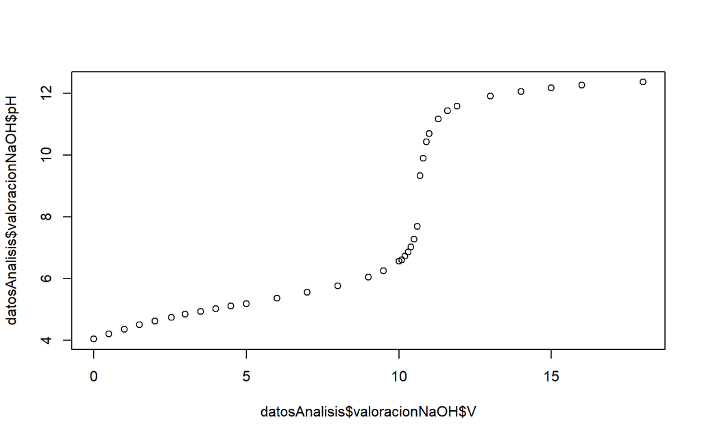

```r
plot(datosAnalisis$valoracionNaOH$V,
     datosAnalisis$valoracionNaOH$pH)
```

```r
pf <- puntoFinal(datosAnalisis$valoracionNaOH$V, datosAnalisis$valoracionNaOH$pH, intervalo_x = c(0, 0))
```

```
##                                      value
## npar                                     5
## params.bottom                  1.07194e-01
## params.top                     9.51810e-01
## params.xmid                    1.10561e+01
## params.scal                    3.08822e+00
## params.s                       2.18218e-01
## GOF                            9.75901e-01
## weightedGOF                    9.99814e-01
## stdErr                          0.05514753
## weighted stdErr                  0.0278536
## trapezoid                           8.3782
## Simpson                             8.2731
## xInfl                               10.842
## yInfl                              0.68754
## Log10(IC50)                       1.023952
## IC50                            1.0567e+01
## [95%]           [1.0394e+01 | 1.07049e+01]
## date (Y-m-d)                    2021-05-31
## nplr version            0.1.7 (2016-12-25)
## R version               4.0.5 (2021-03-31)
```

[figure not shown]

```r
pf$ede$u_PE
```

```
## [1] 0.2602959
```

```r
pf$ede$PE
```

```
## [1] 10.7
```

```r
pf$ede$u_PE/pf$ede$PE*100
```

```
## [1] 2.432672
```

```r
 pf$d1num$u_PE/pf$d1num$PE*100
```

```
## [1] 0.3833317
```

```r
data("EMP_materialVolumetrico")
```

El error máximo permitido es para la temperatura de calibración.

El efecto de la temperatura viene del coeficiente de expansión del solvente e.g. agua.

# Minima cantidad a pesar:

función `masa_minima`

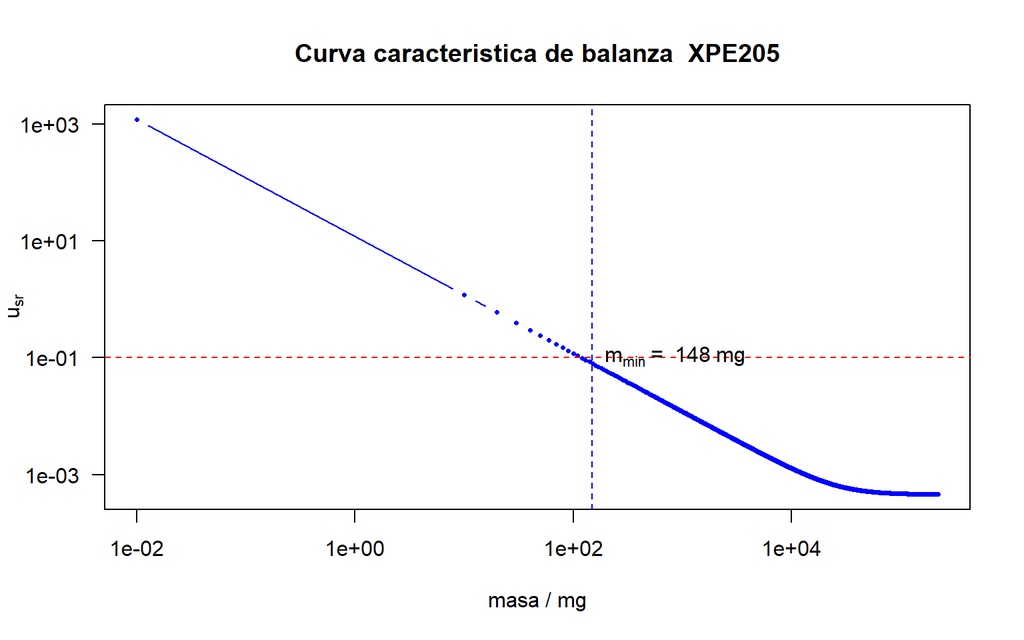

[output not shown]

[output cut: 21990 more lines]

```r
masa <- u_masa(lectura= 0.0601, densidad =1634, balanza = 'XPE205')
masa$m_s$ms # masa corregida por el empuke del aire
```

```
## [1] 0.06012354
```

```r
masa$m_s$u_ms/masa$m_s$ms*100
```

```
## [1] 0.1986355
```

# para nuevas micropipetas

argumento calibracion sesgo incertd.sesgo(en mL) reptibilidad, factor de cobertura (cambiar por $\sqrt{3}$)